# Lab 3 - Exploratory Data Analysis

### 6. Calculate summary statistics

Remember to keep the initial question in mind. We want to pick out the weather station with maximum elevation and examine its windspeed and temperature.

Some ideas: select the weather station with maximum elevation; within this station, look at the correlation between temperature and wind speed; look at the correlation between each of temperature and wind speed with each of hour and day.

```r
# Identify the highest station
max_elev_val <- max(met$elev, na.rm = TRUE)
highest_station <- met[met$elev == max_elev_val & !is.na(met$elev), ]

# Get the unique ID for this station
station_id <- unique(highest_station$USAFID)
cat("Analyzing Station ID:", station_id, "at elevation:", max_elev_val, "meters\n")
```

```
Analyzing Station ID: 720385 at elevation: 4113 meters
```

```r
# Correlation: Temperature vs. Wind Speed
cor_temp_wind <- cor(highest_station$temp, highest_station$wind.sp, use = "complete.obs")

# Correlation: Time-based patterns
# Temperature vs. Hour and Day
cor_temp_hour <- cor(highest_station$temp, highest_station$hour, use = "complete.obs")
cor_temp_day  <- cor(highest_station$temp, highest_station$day, use = "complete.obs")

# Wind Speed vs. Hour and Day
cor_wind_hour <- cor(highest_station$wind.sp, highest_station$hour, use = "complete.obs")
cor_wind_day  <- cor(highest_station$wind.sp, highest_station$day, use = "complete.obs")

# Display results
cat("Correlation (Temp vs Wind Speed):", cor_temp_wind, "\n")
```

```
Correlation (Temp vs Wind Speed): -0.09373843
```

```r
cat("Correlation (Temp vs Hour):", cor_temp_hour, "\n")
```

```
Correlation (Temp vs Hour): 0.4397261
```

```r
cat("Correlation (Wind vs Hour):", cor_wind_hour, "\n")
```

```
Correlation (Wind vs Hour): 0.08807315
```

### 7. Exploratory graphs

We should look at the distributions of all of the key variables to make sure there are no remaining issues with the data. Hint: using the hist function, make histograms of the elev, temp, and wind.sp variables.

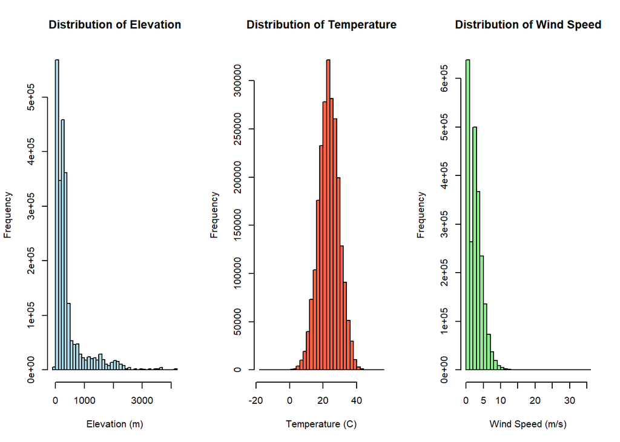

```r
# Set up the plotting window for 3 graphs in one row
par(mfrow = c(1, 3))

# Histogram for Elevation
hist(met$elev,
     main = "Distribution of Elevation",
     xlab = "Elevation (m)",
     col = "lightblue",
     breaks = 50)

# Histogram for Temperature
hist(met$temp,
     main = "Distribution of Temperature",
     xlab = "Temperature (C)",
     col = "tomato",
     breaks = 50)

# Histogram for Wind Speed
hist(met$wind.sp,
     main = "Distribution of Wind Speed",
     xlab = "Wind Speed (m/s)",
     col = "lightgreen",
     breaks = 50)
```

```r
# Reset plotting window to default
par(mfrow = c(1, 1))
```

Note: one thing we should consider for later analyses (not today) is to log transform wind speed and elevation as they are very skewed.

Look at where the weather station with highest elevation is located.

```r
# Identify the highest station coordinates
max_elev_df <- met[met$elev == max(met$elev, na.rm = TRUE) & !is.na(met$elev), ]

high_station_loc <- unique(max_elev_df[, c("lat", "lon")])

leaflet(high_station_loc) %>%
  addProviderTiles('OpenStreetMap') %>%
  addCircles(lat=~lat, lng=~lon, opacity=1, fillOpacity=1, radius=100, color="red")
```

[interactive chart not shown]

Look at the time series of temperature and wind speed at this location. For this we will need to create a date-time variable for the x-axis.

```r
library(lubridate)
max_elev_df$date <- with(max_elev_df, ymd_h(paste(year, month, day, hour, sep= ' ')))
max_elev_df <- max_elev_df[order(max_elev_df$date), ]

# Plot Temperature Time Series
plot(max_elev_df$date, max_elev_df$temp,
     type = "l",
     col = "red",
     main = "Temperature at Highest Elevation",
     xlab = "Date", ylab = "Temp (C)")

# Plot Wind Speed Time Series
plot(max_elev_df$date, max_elev_df$wind.sp,
     type = "l",
     col = "blue",
     main = "Wind Speed at Highest Elevation",
     xlab = "Date", ylab = "Wind Speed (m/s)")
```

[output not shown]

Given the date-time variable, plot the time series of temperature and also wind speed.

- Summarize any trends that you see in these time series plots. Ans: Temperatures peak in the late afternoon and drop sharply overnight.Wind: Spiky distribution with no smooth daily rhythm.